# snowflakes

2023-03-04

The data we have is from a PhD student at an EPFL lab regarding snow-flake diameters. The data is binned with non-uniform bin-length. We remove the bins with zero entries and look at the data. We see a bi-modal distribution on making a histogram of the data.

We know that the data is supposed to be a mixture of two log-normal distributions which is not contrary to the expert knowledge as the data is bi modal.

```r
library(ggplot2)
#the hstogram for the binned data will not change even if we introduce the randomness as long as we use the same breakpoints. Thus, we do a histogram of this jittered data which is identical to the histogram we want.
jitter_function= function(snowdata2 = snowdata){
jittereddataset = rep(0, 1)
counter = 1
increment = 0
num_loop = which(snowdata2$retained.... == 0)[1] - 1
for(i in 1:num_loop){
  increment = as.integer(snowdata2$retained....[i]*snowdata2$particles.detected[i]/100)
  jittereddataset[counter:(counter+increment)] =   runif(increment, min = snowdata2$startpoint[i], max = snowdata2$endpoint[i])
  counter = counter + increment
}
return(jittereddataset)
}
plot = ggplot()+
 geom_histogram(mapping = aes(x = jitter_function(), y = ..density..), breaks = c(snowdata$endpoint[1:47], 0))+
  xlab('Snowflake Diameters')+
  ylab('Density')
```

We see from the histogram of the data that indeed, the data is bi modal and non-negative. Thus, a mixture of log normal densities can be a good candidate model in this case.

We try to fit the data to a mixture of the log normal densities using EM and optimisation. First, we introduce randomness in the data by selecting the required number of points in each interval uniformly at random. After doing EM on this using the bi-log-normal likelihood, we obtain a good candidate for the starting value for optimising the real likelihood of the binned data. In each case, we use the log likelihood for better optimisation.

```r
#jitter and em
#jittered data set construction
dmixlnorm <- function(x, mu1, mu2, sigma1, sigma2, tau){
  y <- (1-tau)*dlnorm(x,mu1,sigma1) + tau*dlnorm(x,mu2,sigma2)
  return(y)
}
pmixlnorm <- function(x, mu1, mu2, sigma1, sigma2, tau){
  y <- (1-tau)*plnorm(x,mu1,sigma1) + tau*plnorm(x,mu2,sigma2)
  return(y)
}
rmixlnorm <- function(n, mu1, mu2, sigma1, sigma2, tau){
  unifs = runif(n)
  indicators = unifs<0.5
  answer = indicators*rlnorm(n, mu1, sigma1) + (1 - indicators)*rlnorm(n, mu2, sigma2)
  return(answer)
}
likelihood <- function(x, mu1, mu2, sigma1, sigma2, tau){
  temp = 0
  for (i in 1:length(x)) {
    temp = temp + log(dmixlnorm(x[i], mu1,mu2,sigma1, sigma2, tau))
  }
  return(temp)
}
reallikelihood = function( params){
  mu1 = params[1]
  mu2 = params[2]
  sigma1 = exp(params[3])
  sigma2 = exp(params[4])
  tau = 1/(1 + exp(params[5]))
  temp = 0
  snowdata3 = snowdata
  snowdata3$number = as.integer(snowdata3$retained....*snowdata3$particles.detected/100)
  for(i in 1:nrow(snowdata3)){
    temp = temp +snowdata3[i,6] * log(pmixlnorm(snowdata3[i,3],mu1, mu2, sigma1, sigma2, tau) - pmixlnorm(snowdata3[i,2], mu1, mu2, sigma1, sigma2, tau))
  }
  return(-temp)
}


em_function = function(snowdata2 = snowdata){
sample = jitter_function(snowdata2)
N = length(sample)
mu1 = -2
mu2 = -0.6
sigma1_sq = 1
sigma2_sq = 4
tau = 0.8
likelihood_obs = likelihood(sample,  mu1, mu2, sigma1_sq, sigma2_sq, tau)
p = rep(0, N)
piece1 = dlnorm(sample ,mean = mu2, sd = sqrt(sigma2_sq))*tau
piece2 = dmixlnorm(sample, mu1, mu2, sqrt(sigma1_sq), sqrt(sigma2_sq), tau)
p = piece1/piece2
next_tau = sum(p)/N
next_mu1 = (sum((1-p)*log(sample)))/(N - sum(p))
next_mu2 = sum(p*log(sample))/sum(p)
next_sigma1_sq = sum((1-p)*((log(sample) - next_mu1)**2))/(N - sum(p))
next_sigma2_sq = sum(p*(log(sample) - next_mu2)**2)/sum(p)
likelihood_obs_next = likelihood(sample, next_mu1,next_mu2,sqrt(next_sigma1_sq),sqrt(next_sigma2_sq),next_tau)
tau = next_tau
mu1 = next_mu1
mu2 = next_mu2
sigma1_sq = next_sigma1_sq
sigma2_sq = next_sigma2_sq
iter = 1
tol = 50
while (abs(likelihood_obs_next - likelihood_obs) > tol) {
  piece1 = dlnorm(sample ,mean = mu2, sd = sqrt(sigma2_sq))*tau
  piece2 = dmixlnorm(sample, mu1, mu2, sqrt(sigma1_sq), sqrt(sigma2_sq), tau)
  p = piece1/piece2
  next_tau = sum(p)/N
  next_mu1 = (sum((1-p)*log(sample)))/(N - sum(p))
  next_mu2 = sum(p*log(sample))/sum(p)
  next_sigma1_sq = sum((1-p)*((log(sample) - next_mu1)**2))/(N - sum(p))
  next_sigma2_sq = sum(p*(log(sample) - next_mu2)**2)/sum(p)
  likelihood_obs = likelihood_obs_next
  likelihood_obs_next = likelihood(sample, next_mu1,next_mu2,sqrt(next_sigma1_sq),sqrt(next_sigma2_sq),next_tau)
  tau = next_tau
  mu1 = next_mu1
  mu2 = next_mu2
  sigma1_sq = next_sigma1_sq
  sigma2_sq = next_sigma2_sq
  iter = iter + 1
}
params = c(next_mu1,next_mu2,sqrt(next_sigma1_sq),sqrt(next_sigma2_sq),next_tau)
return(params)
}
opt_function= function(snowdata3 = snowdata){
#now, we have unconstrained optimisation. Thus, we transform the paramters so that they are on the real line.
#no change from mu1 and mu2
log_sigma_1 = log(sqrt(sigma1_sq))
log_sigma_2 = log(sqrt(sigma2_sq))
trans_tau = log(1/tau - 1)
trans_params =  c(mu1,mu2,log_sigma_1,log_sigma_2,trans_tau)

final = optim(par = trans_params, reallikelihood)
params_final = final$par
params_final[3:4] = exp(params_final[3:4])
params_final[5] = 1/(1 + exp(params_final[5]))
return(params_final)
}
params = em_function()
```

[output not shown]

[output cut: 79 more lines]

[output not shown]

[output not shown]

[output cut: 214 more lines]

[output not shown]

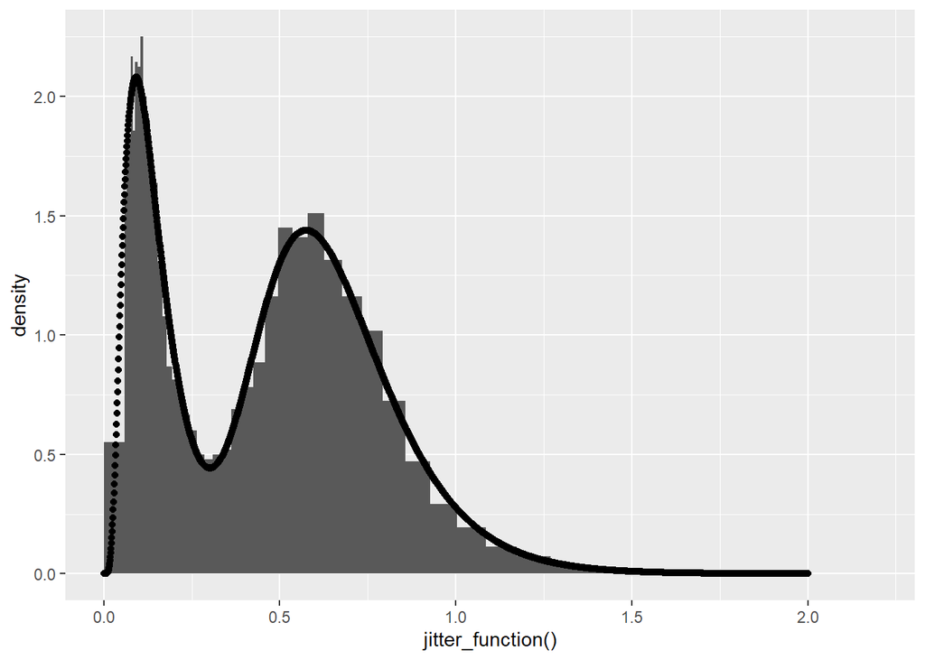

```r
mu1 = params[1];mu2 = params[2];sigma1_sq   = params[3];sigma2_sq = params[4]
tau =params[5]
params_final = opt_function()
temp = seq(0,2,0.001)

ggplot()+
 geom_histogram(mapping = aes(x = jitter_function(), y = ..density..), breaks = c(snowdata$endpoint[1:47], 0))+
 geom_point(mapping=aes(x = temp, y = dmixlnorm(temp, params_final[1],params_final[2],params_final[3], params_final[4], params_final[5])))
```

```r
hist(jitter_function(), breaks = c(snowdata$endpoint[1:47], 0))
```

[output not shown]

[output cut: 79 more lines]

[output not shown]

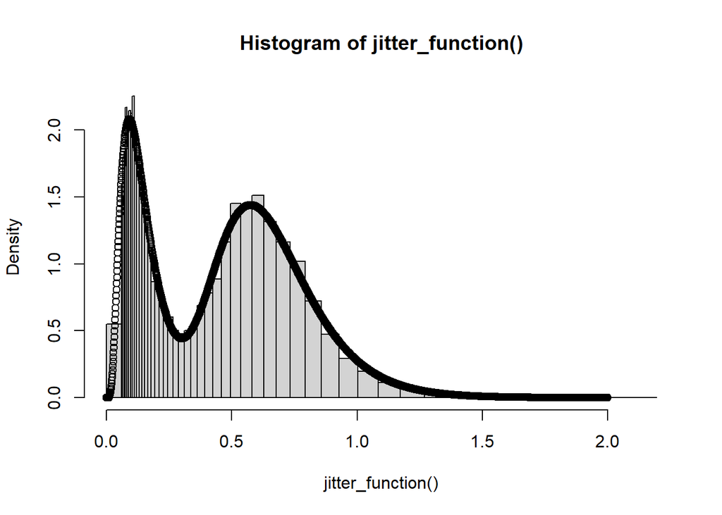

```r
points(temp,dmixlnorm(temp, params_final[1],params_final[2],params_final[3], params_final[4],  params_final[5]))
```